# Introduction to R Programming

Dr. Lema LS

2025-09-12

## Operators, variables and data types in R

- To insert a new chunk, use the shortcut `Crtl + Alt + I`.
- We can `source` an `.R` in a `.R` or `.Rmd`. It is useful when you are building an app and you want all your written functions to be in one file.

```r
source("R_day1-R-fundamentals.R")
```

```
## [1] "Hello, World!"
## [1] "2"   "8"   "9"   NA    "0"   "Inf"
## [1]   2   8   9  NA   0 Inf   1   0   1
```

Note that only the `print(...)`s from the `.R` file are displayed.

## Day 2: Data types

```r
set.seed(123) # reproducibility (fixing the randomness)
dice = sample(6, size = 100, replace = TRUE)
dice
```

```
##   [1] 3 6 3 2 2 6 3 5 4 6 6 1 2 3 5 3 3 1 4 1 1 5 3 2 2 1 6 3 4 6 1 3 5 4 2 5 1
##  [38] 1 2 3 4 5 5 3 6 1 2 5 5 4 5 2 1 1 3 1 6 5 1 2 4 4 6 6 3 6 6 1 6 2 1 2 4 5
##  [75] 5 6 3 1 4 6 1 6 1 3 6 4 1 6 6 3 6 5 3 6 2 5 5 3 2 2
```

```r
length(dice)
```

```
## [1] 100
```

If I want to check which number in `dice` is equal to 6, I use the logical operator `==`.

```r
dice == 6
```

```
##   [1] FALSE  TRUE FALSE FALSE FALSE  TRUE FALSE FALSE FALSE  TRUE  TRUE FALSE
##  [13] FALSE FALSE FALSE FALSE FALSE FALSE FALSE FALSE FALSE FALSE FALSE FALSE
##  [25] FALSE FALSE  TRUE FALSE FALSE  TRUE FALSE FALSE FALSE FALSE FALSE FALSE
##  [37] FALSE FALSE FALSE FALSE FALSE FALSE FALSE FALSE  TRUE FALSE FALSE FALSE
##  [49] FALSE FALSE FALSE FALSE FALSE FALSE FALSE FALSE  TRUE FALSE FALSE FALSE
##  [61] FALSE FALSE  TRUE  TRUE FALSE  TRUE  TRUE FALSE  TRUE FALSE FALSE FALSE
##  [73] FALSE FALSE FALSE  TRUE FALSE FALSE FALSE  TRUE FALSE  TRUE FALSE FALSE
##  [85]  TRUE FALSE FALSE  TRUE  TRUE FALSE  TRUE FALSE FALSE  TRUE FALSE FALSE
##  [97] FALSE FALSE FALSE FALSE
```

```r
# use the sum function to calculate the number of 6 in the variable dice.
sum(dice == 6) # gives the count of 6 in dice
```

```
## [1] 21
```

```r
mean(dice == 6) # gives the proportion of 6 in dice
```

```
## [1] 0.21
```

```r
# use table function to get counts for all categories
table(dice)
```

```
## dice
##  1  2  3  4  5  6
## 19 15 18 11 16 21
```

```r
# prop.table to calculate proportions for all categories in dice.
prop.table(table(dice))
```

```
## dice
##    1    2    3    4    5    6
## 0.19 0.15 0.18 0.11 0.16 0.21
```

### Generate a vector using `rep`

```r
(names3x <- rep("Lema", 3))
```

```
## [1] "Lema" "Lema" "Lema"
```

```r
(x <- rep(0, 10))
```

```
##  [1] 0 0 0 0 0 0 0 0 0 0
```

**Exercise:** Write an R code to generate 1 1 1 1 0 0 0 0 0 1 2 3 4 6 5 4 3 2 0 0 0 0 2 2 2 2 2 2 2 -1

```r
c(rep(1, 4), rep(0, 5), 1:4, 6:2, rep(0, 4), rep(2, 7), 2-3)
```

```
##  [1]  1  1  1  1  0  0  0  0  0  1  2  3  4  6  5  4  3  2  0  0  0  0  2  2  2
## [26]  2  2  2  2 -1
```

```r
c(rep(c(1, 0), c(4, 5)), 1:4, 6:2, rep(c(0, 2), c(4, 7)), -1)
```

```
##  [1]  1  1  1  1  0  0  0  0  0  1  2  3  4  6  5  4  3  2  0  0  0  0  2  2  2
## [26]  2  2  2  2 -1
```

### Operations on vectors

```r
vect1 <- c(2, 3, 5, 6, 8)
vect2 <- c(1, 3, 5, 8, 10)

vect1 + vect2 # add
```

```
## [1]  3  6 10 14 18
```

```r
vect1 * vect2 # element-wise multiplication
```

```
## [1]  2  9 25 48 80
```

```r
vect1 / vect2 # element-wise division
```

```
## [1] 2.00 1.00 1.00 0.75 0.80
```

```r
vect1 %*% vect2 # dot product
```

```
##      [,1]
## [1,]  164
```

```r
# multiplication by a scalar
k = 2
k * vect1
```

```
## [1]  4  6 10 12 16
```

```r
vect1 ** k
```

```
## [1]  4  9 25 36 64
```

```r
vect1 %% k
```

```
## [1] 0 1 1 0 0
```

```r
vect1 - k
```

```
## [1] 0 1 3 4 6
```

```r
vect1 + k
```

```
## [1]  4  5  7  8 10
```

```r
vect1 %/% k
```

```
## [1] 1 1 2 3 4
```

```r
mean(vect1)
```

```
## [1] 4.8
```

```r
min(vect1)
```

```
## [1] 2
```

```r
max(vect1)
```

```
## [1] 8
```

```r
range(vect1)
```

```
## [1] 2 8
```

```r
summary(vect1)
```

```
##    Min. 1st Qu.  Median    Mean 3rd Qu.    Max.
##     2.0     3.0     5.0     4.8     6.0     8.0
```

### Vectors from distributions

#### Normal distribution

A variable $X$ is normally distributed, or $X\sim N(\mu, \sigma^2)$, if:

$$f_X(x) =
\frac{1}{\sqrt{2\pi\sigma^2}}\exp\left\{-\frac{(x-\mu)^2}{2\sigma^2}\right\},
\quad x\in\mathbb{R}.$$
Note that $\mu$ and $\sigma$ are respectively population mean and standard deviation.

From those two parameter we can be able to generate a sample `x_rnorm`.

```r
set.seed(123)
(x_norm <- rnorm(150, 60, 10))
```

```
##   [1] 54.39524 57.69823 75.58708 60.70508 61.29288 77.15065 64.60916 47.34939
##   [9] 53.13147 55.54338 72.24082 63.59814 64.00771 61.10683 54.44159 77.86913
##  [17] 64.97850 40.33383 67.01356 55.27209 49.32176 57.82025 49.73996 52.71109
##  [25] 53.74961 43.13307 68.37787 61.53373 48.61863 72.53815 64.26464 57.04929
##  [33] 68.95126 68.78133 68.21581 66.88640 65.53918 59.38088 56.94037 56.19529
##  [41] 53.05293 57.92083 47.34604 81.68956 72.07962 48.76891 55.97115 55.33345
##  [49] 67.79965 59.16631 62.53319 59.71453 59.57130 73.68602 57.74229 75.16471
##  [57] 44.51247 65.84614 61.23854 62.15942 63.79639 54.97677 56.66793 49.81425
##  [65] 49.28209 63.03529 64.48210 60.53004 69.22267 80.50085 55.08969 36.90831
##  [73] 70.05739 52.90799 53.11991 70.25571 57.15227 47.79282 61.81303 58.61109
##  [81] 60.05764 63.85280 56.29340 66.44377 57.79513 63.31782 70.96839 64.35181
##  [89] 56.74068 71.48808 69.93504 65.48397 62.38732 53.72094 73.60652 53.99740
##  [97] 81.87333 75.32611 57.64300 49.73579 52.89593 62.56884 57.53308 56.52457
## [105] 50.48381 59.54972 52.15096 43.32058 56.19773 69.18997 54.24653 66.07964
## [113] 43.82117 59.44438 65.19407 63.01153 61.05676 53.59294 51.50296 49.75871
## [121] 61.17647 50.52525 55.09443 57.43908 78.43862 53.48050 62.35387 60.77961
## [129] 50.38143 59.28692 74.44551 64.51504 60.41233 55.77503 39.46753 71.31337
## [137] 45.39360 67.39948 79.09104 45.56107 67.01784 57.37803 44.27856 44.85332
## [145] 43.98464 54.69093 45.38244 66.87917 81.00109 47.12970
```

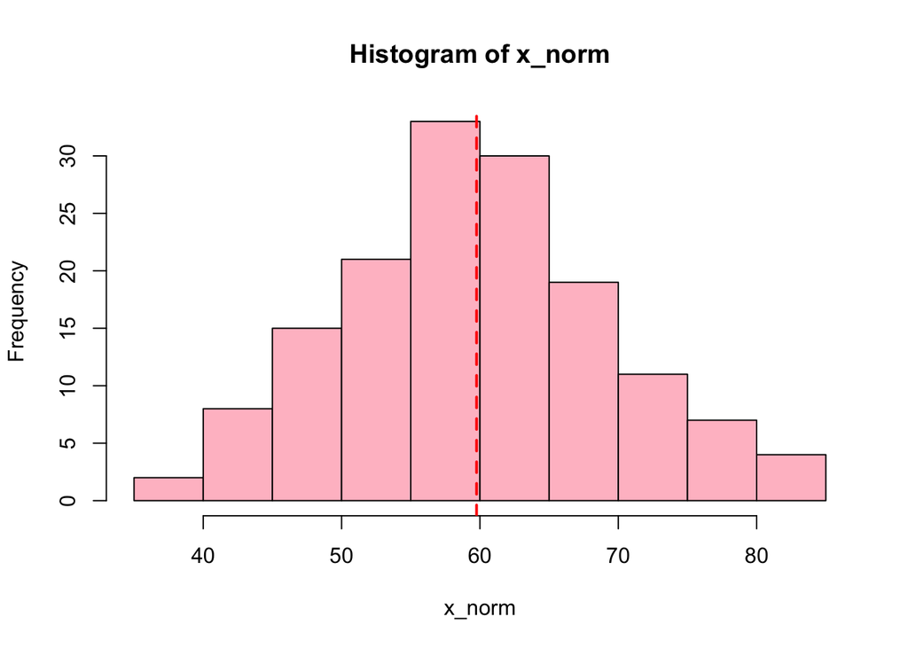

```r
hist(x_norm, col = "pink")
abline(v = mean(x_norm), col = "red", lwd = 2, lty = 2)
```

```r
# ?rnorm # ? brings the help/doc of a specific function
```

Let’s now use the sample to compute:

- sample mean $\bar x= \displaystyle\frac{1}{n}\sum_{i=1}^nx_i$

```r
mean(x_norm)
```

```
## [1] 59.75637
```

```r
sd(x_norm)
```

```
## [1] 9.497506
```

### Poison distribution

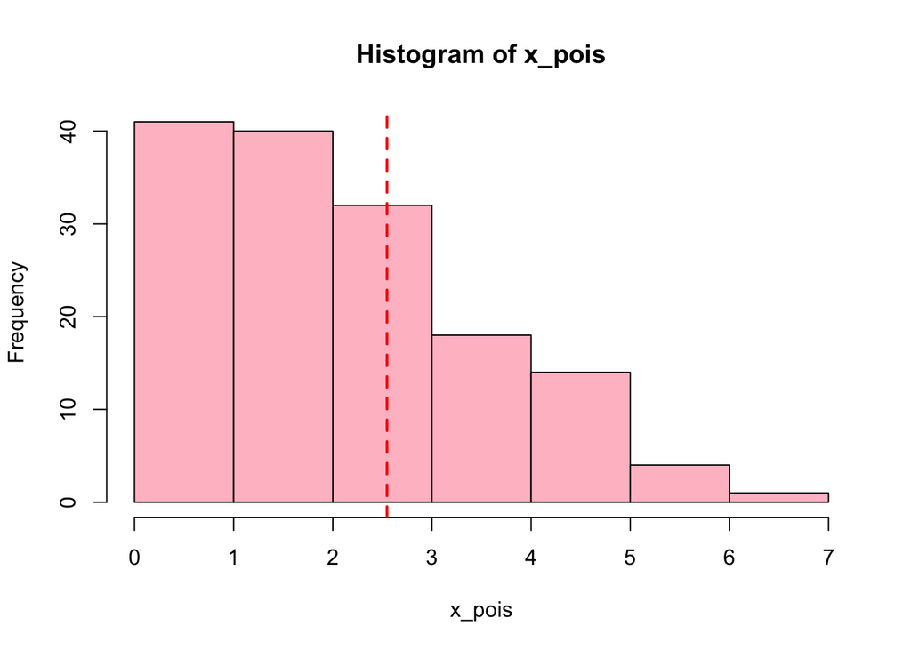

```r
# ?rpois
set.seed(123)
x_pois <- rpois(n = 150, 2.5)
hist(x_pois, col = "pink")
abline(v = mean(x_pois), col = "red", lwd = 2, lty = 2)
```

## Arrays (vectors - 1D, matrives - 2D, ND)

### Matrices

```r
# use dim to reshape a ID to 2D
v <- 1:9
dim(v) <- c(3, 3)
v
```

```
##      [,1] [,2] [,3]
## [1,]    1    4    7
## [2,]    2    5    8
## [3,]    3    6    9
```

```r
# use matrix() to create a matrix
(M1 <- matrix(1:9, nrow = 3)) # byrow = F by default.
```

```
##      [,1] [,2] [,3]
## [1,]    1    4    7
## [2,]    2    5    8
## [3,]    3    6    9
```

```r
(M2 <- matrix(1:9, nrow = 3, byrow = T)) # byrow = F by default.
```

```
##      [,1] [,2] [,3]
## [1,]    1    2    3
## [2,]    4    5    6
## [3,]    7    8    9
```

M2 and M1 transpose of each other.

```r
all((t(M2) == M1) == T) # isTRUE
```

```
## [1] TRUE
```

```r
identical(t(M2), M1)
```

```
## [1] TRUE
```

- Indexing and slicing

```r
set.seed(123)
(v <- sample(100, size = 9))
```

```
## [1] 31 79 51 14 67 42 50 43 97
```

```r
v[1] # prints the 1st element of v
```

```
## [1] 31
```

```r
v = v[-1] # drops the fist element
v[length(v)]
```

```
## [1] 97
```

```r
v[v == 50]
```

```
## [1] 50
```

```r
v[which(v == 50)]
```

```
## [1] 50
```

```r
v
```

```
## [1] 79 51 14 67 42 50 43 97
```

```r
v > 50
```

```
## [1]  TRUE  TRUE FALSE  TRUE FALSE FALSE FALSE  TRUE
```

```r
v[v > 50]
```

```
## [1] 79 51 67 97
```

```r
M2[3, -1] # delete the first element of the 3rd row.
```

```
## [1] 8 9
```

```r
M2[, -1] # drops the first column of M2
```

```
##      [,1] [,2]
## [1,]    2    3
## [2,]    5    6
## [3,]    8    9
```

```r
M2[-2, ]
```

```
##      [,1] [,2] [,3]
## [1,]    1    2    3
## [2,]    7    8    9
```

```r
M2[1,1] # print the element at row 1 and col 1
```

```
## [1] 1
```

```r
M2
```

```
##      [,1] [,2] [,3]
## [1,]    1    2    3
## [2,]    4    5    6
## [3,]    7    8    9
```

```r
set.seed(123)
v[sample(length(v), 3)] <- NA
v
```

```
## [1] 79 51 NA 67 42 50 NA NA
```

```r
# use is.na(v) test if a value in v is missing
v[is.na(v)] <- round(mean(v, na.rm = TRUE), 2)
```

```r
v
```

```
## [1] 79.0 51.0 57.8 67.0 42.0 50.0 57.8 57.8
```

## Operations on matrices

```r
A <- matrix(c(3, 1, 0, 0, -1, 5, 7, 8, 1), ncol = 3, byrow = TRUE)
set.seed(123)
B <- matrix(round(runif(9), 2), ncol = 3) # runif generate a sample from uniform dist.
A; B
```

```
##      [,1] [,2] [,3]
## [1,]    3    1    0
## [2,]    0   -1    5
## [3,]    7    8    1
```

```
##      [,1] [,2] [,3]
## [1,] 0.29 0.88 0.53
## [2,] 0.79 0.94 0.89
## [3,] 0.41 0.05 0.55
```

```r
# add
A + B
```

```
##      [,1]  [,2] [,3]
## [1,] 3.29  1.88 0.53
## [2,] 0.79 -0.06 5.89
## [3,] 7.41  8.05 1.55
```

```r
# element-wise multiplication
A * B
```

```
##      [,1]  [,2] [,3]
## [1,] 0.87  0.88 0.00
## [2,] 0.00 -0.94 4.45
## [3,] 2.87  0.40 0.55
```

```r
# element-wise subtraction
A - B
```

```
##       [,1]  [,2]  [,3]
## [1,]  2.71  0.12 -0.53
## [2,] -0.79 -1.94  4.11
## [3,]  6.59  7.95  0.45
```

```r
# element-wise division
A / B
```

```
##          [,1]       [,2]     [,3]
## [1,] 10.34483   1.136364 0.000000
## [2,]  0.00000  -1.063830 5.617978
## [3,] 17.07317 160.000000 1.818182
```

```r
# matrix multiplication (dot product)
A %*% A # not (A^2 which is element-wise exponentiation)
```

```
##      [,1] [,2] [,3]
## [1,]    9    2    5
## [2,]   35   41    0
## [3,]   28    7   41
```

```r
Ainv <- solve(A)
round(Ainv %*% A, 10)
```

```
##      [,1] [,2] [,3]
## [1,]    1    0    0
## [2,]    0    1    0
## [3,]    0    0    1
```

```r
A2 <- matrix(c(1, 1, 1, -1), nrow = 2, byrow = TRUE)
b <- c(2, 0)
solve(A2, b)
```

```
## [1] 1 1
```

# Eigen values -vectors

```r
evA <- eigen(A)
evA$values
```

```
## [1]  7.046271 -6.095230  2.048959
```

```r
evA$vectors
```

```
##            [,1]        [,2]       [,3]
## [1,] -0.1293458  0.07678066 -0.6680328
## [2,] -0.5233681 -0.69833777  0.6353268
## [3,] -0.8422324  0.71163831  0.3874170
```

## Lists

```r
mylist <- list(matrix = A, bool = is.matrix(A), data = head(iris, 3))
# iris is an inbuilt dataset. Use ?iris to check the documentation of iris.
print(mylist)
```

```
## $matrix
##      [,1] [,2] [,3]
## [1,]    3    1    0
## [2,]    0   -1    5
## [3,]    7    8    1
##
## $bool
## [1] TRUE
##
## $data
##   Sepal.Length Sepal.Width Petal.Length Petal.Width Species
## 1          5.1         3.5          1.4         0.2  setosa
## 2          4.9         3.0          1.4         0.2  setosa
## 3          4.7         3.2          1.3         0.2  setosa
```

```r
mylist$matrix[3, 2]
```

```
## [1] 8
```

```r
# write a code that will print the last setosa from mylist.
n <- nrow(mylist$data)
p <- ncol(mylist$data)
n; p
```

```
## [1] 3
```

```
## [1] 5
```

```r
mylist$data[n, p]
```

```
## [1] setosa
## Levels: setosa versicolor virginica
```

```r
mylist$data$Sepal.Width[2]
```

```
## [1] 3
```

## Data frames

```r
head(iris)
```

```
##   Sepal.Length Sepal.Width Petal.Length Petal.Width Species
## 1          5.1         3.5          1.4         0.2  setosa
## 2          4.9         3.0          1.4         0.2  setosa
## 3          4.7         3.2          1.3         0.2  setosa
## 4          4.6         3.1          1.5         0.2  setosa
## 5          5.0         3.6          1.4         0.2  setosa
## 6          5.4         3.9          1.7         0.4  setosa
```

```r
?data # help("iris")
```

## Data Exploration

```r
# data dimensions
dim(iris) # iris is already existing (inbuilt data)
```

```
## [1] 150   5
```

```r
paste("Lema", "Logamou")
```

```
## [1] "Lema Logamou"
```

```r
cat(paste0("Lema", "Logamou"))
```

```
## LemaLogamou
```

```r
cat(paste0("My iris data has ", dim(iris)[1], " rows and ", dim(iris)[2], " columns.\n"))
```

```
## My iris data has 150 rows and 5 columns.
```

```r
cat("My iris data has", nrow(iris), "rows and", ncol(iris), "columns.")
```

```
## My iris data has 150 rows and 5 columns.
```

```r
# data structure
str(iris)
```

```
## 'data.frame':    150 obs. of  5 variables:
##  $ Sepal.Length: num  5.1 4.9 4.7 4.6 5 5.4 4.6 5 4.4 4.9 ...
##  $ Sepal.Width : num  3.5 3 3.2 3.1 3.6 3.9 3.4 3.4 2.9 3.1 ...
##  $ Petal.Length: num  1.4 1.4 1.3 1.5 1.4 1.7 1.4 1.5 1.4 1.5 ...
##  $ Petal.Width : num  0.2 0.2 0.2 0.2 0.2 0.4 0.3 0.2 0.2 0.1 ...
##  $ Species     : Factor w/ 3 levels "setosa","versicolor",..: 1 1 1 1 1 1 1 1 1 1 ...
```

```r
as.character(iris$Species)
```

```
##   [1] "setosa"     "setosa"     "setosa"     "setosa"     "setosa"
##   [6] "setosa"     "setosa"     "setosa"     "setosa"     "setosa"
##  [11] "setosa"     "setosa"     "setosa"     "setosa"     "setosa"
##  [16] "setosa"     "setosa"     "setosa"     "setosa"     "setosa"
##  [21] "setosa"     "setosa"     "setosa"     "setosa"     "setosa"
##  [26] "setosa"     "setosa"     "setosa"     "setosa"     "setosa"
##  [31] "setosa"     "setosa"     "setosa"     "setosa"     "setosa"
##  [36] "setosa"     "setosa"     "setosa"     "setosa"     "setosa"
##  [41] "setosa"     "setosa"     "setosa"     "setosa"     "setosa"
##  [46] "setosa"     "setosa"     "setosa"     "setosa"     "setosa"
##  [51] "versicolor" "versicolor" "versicolor" "versicolor" "versicolor"
##  [56] "versicolor" "versicolor" "versicolor" "versicolor" "versicolor"
##  [61] "versicolor" "versicolor" "versicolor" "versicolor" "versicolor"
##  [66] "versicolor" "versicolor" "versicolor" "versicolor" "versicolor"
##  [71] "versicolor" "versicolor" "versicolor" "versicolor" "versicolor"
##  [76] "versicolor" "versicolor" "versicolor" "versicolor" "versicolor"
##  [81] "versicolor" "versicolor" "versicolor" "versicolor" "versicolor"
##  [86] "versicolor" "versicolor" "versicolor" "versicolor" "versicolor"
##  [91] "versicolor" "versicolor" "versicolor" "versicolor" "versicolor"
##  [96] "versicolor" "versicolor" "versicolor" "versicolor" "versicolor"
## [101] "virginica"  "virginica"  "virginica"  "virginica"  "virginica"
## [106] "virginica"  "virginica"  "virginica"  "virginica"  "virginica"
## [111] "virginica"  "virginica"  "virginica"  "virginica"  "virginica"
## [116] "virginica"  "virginica"  "virginica"  "virginica"  "virginica"
## [121] "virginica"  "virginica"  "virginica"  "virginica"  "virginica"
## [126] "virginica"  "virginica"  "virginica"  "virginica"  "virginica"
## [131] "virginica"  "virginica"  "virginica"  "virginica"  "virginica"
## [136] "virginica"  "virginica"  "virginica"  "virginica"  "virginica"
## [141] "virginica"  "virginica"  "virginica"  "virginica"  "virginica"
## [146] "virginica"  "virginica"  "virginica"  "virginica"  "virginica"
```

```r
# data summary
summary(iris$Sepal.Length)
```

```
##    Min. 1st Qu.  Median    Mean 3rd Qu.    Max.
##   4.300   5.100   5.800   5.843   6.400   7.900
```

```r
# summary of categorical variable is just like table()
summary(iris$Species)
```

```
##     setosa versicolor  virginica
##         50         50         50
```

```r
# proportion table
prop.table(summary(iris$Species)) # table(iris$Species)
```

```
##     setosa versicolor  virginica
##  0.3333333  0.3333333  0.3333333
```

```r
iris$new_column <- NA # adding a new_column.
head(iris)
```

```
##   Sepal.Length Sepal.Width Petal.Length Petal.Width Species new_column
## 1          5.1         3.5          1.4         0.2  setosa         NA
## 2          4.9         3.0          1.4         0.2  setosa         NA
## 3          4.7         3.2          1.3         0.2  setosa         NA
## 4          4.6         3.1          1.5         0.2  setosa         NA
## 5          5.0         3.6          1.4         0.2  setosa         NA
## 6          5.4         3.9          1.7         0.4  setosa         NA
```

```r
View(iris)

iris$new_column <- NULL # drops the new_column
iris_clean <- iris[, -ncol(iris)] # deletes the last column of iris

names(iris)
```

```
## [1] "Sepal.Length" "Sepal.Width"  "Petal.Length" "Petal.Width"  "Species"
```

```r
iris[-(1:ncol(iris))]
```

```
## data frame with 0 columns and 150 rows
```

```r
idx_pl <- which(names(iris) == "Petal.Length")
iris[-idx_pl]
```

```
##     Sepal.Length Sepal.Width Petal.Width    Species
## 1            5.1         3.5         0.2     setosa
## 2            4.9         3.0         0.2     setosa
## 3            4.7         3.2         0.2     setosa
## 4            4.6         3.1         0.2     setosa
## 5            5.0         3.6         0.2     setosa
## 6            5.4         3.9         0.4     setosa
## 7            4.6         3.4         0.3     setosa
## 8            5.0         3.4         0.2     setosa
## 9            4.4         2.9         0.2     setosa
## 10           4.9         3.1         0.1     setosa
## 11           5.4         3.7         0.2     setosa
## 12           4.8         3.4         0.2     setosa
## 13           4.8         3.0         0.1     setosa
## 14           4.3         3.0         0.1     setosa
```

[output cut: 136 more lines]

### Column(s) selection

```r
iris[c("Petal.Length", "Species")]
```

```
##     Petal.Length    Species
## 1            1.4     setosa
## 2            1.4     setosa
## 3            1.3     setosa
## 4            1.5     setosa
## 5            1.4     setosa
## 6            1.7     setosa
## 7            1.4     setosa
## 8            1.5     setosa
## 9            1.4     setosa
## 10           1.5     setosa
## 11           1.5     setosa
## 12           1.6     setosa
## 13           1.4     setosa
## 14           1.1     setosa
```

[output cut: 136 more lines]

```r
iris[["Petal.Length"]]
```

```
##   [1] 1.4 1.4 1.3 1.5 1.4 1.7 1.4 1.5 1.4 1.5 1.5 1.6 1.4 1.1 1.2 1.5 1.3 1.4
##  [19] 1.7 1.5 1.7 1.5 1.0 1.7 1.9 1.6 1.6 1.5 1.4 1.6 1.6 1.5 1.5 1.4 1.5 1.2
##  [37] 1.3 1.4 1.3 1.5 1.3 1.3 1.3 1.6 1.9 1.4 1.6 1.4 1.5 1.4 4.7 4.5 4.9 4.0
##  [55] 4.6 4.5 4.7 3.3 4.6 3.9 3.5 4.2 4.0 4.7 3.6 4.4 4.5 4.1 4.5 3.9 4.8 4.0
##  [73] 4.9 4.7 4.3 4.4 4.8 5.0 4.5 3.5 3.8 3.7 3.9 5.1 4.5 4.5 4.7 4.4 4.1 4.0
##  [91] 4.4 4.6 4.0 3.3 4.2 4.2 4.2 4.3 3.0 4.1 6.0 5.1 5.9 5.6 5.8 6.6 4.5 6.3
## [109] 5.8 6.1 5.1 5.3 5.5 5.0 5.1 5.3 5.5 6.7 6.9 5.0 5.7 4.9 6.7 4.9 5.7 6.0
## [127] 4.8 4.9 5.6 5.8 6.1 6.4 5.6 5.1 5.6 6.1 5.6 5.5 4.8 5.4 5.6 5.1 5.1 5.9
## [145] 5.7 5.2 5.0 5.2 5.4 5.1
```

```r
attach(iris)
Species
```

```
##   [1] setosa     setosa     setosa     setosa     setosa     setosa
##   [7] setosa     setosa     setosa     setosa     setosa     setosa
##  [13] setosa     setosa     setosa     setosa     setosa     setosa
##  [19] setosa     setosa     setosa     setosa     setosa     setosa
##  [25] setosa     setosa     setosa     setosa     setosa     setosa
##  [31] setosa     setosa     setosa     setosa     setosa     setosa
##  [37] setosa     setosa     setosa     setosa     setosa     setosa
##  [43] setosa     setosa     setosa     setosa     setosa     setosa
##  [49] setosa     setosa     versicolor versicolor versicolor versicolor
##  [55] versicolor versicolor versicolor versicolor versicolor versicolor
##  [61] versicolor versicolor versicolor versicolor versicolor versicolor
##  [67] versicolor versicolor versicolor versicolor versicolor versicolor
##  [73] versicolor versicolor versicolor versicolor versicolor versicolor
##  [79] versicolor versicolor versicolor versicolor versicolor versicolor
##  [85] versicolor versicolor versicolor versicolor versicolor versicolor
##  [91] versicolor versicolor versicolor versicolor versicolor versicolor
##  [97] versicolor versicolor versicolor versicolor virginica  virginica
## [103] virginica  virginica  virginica  virginica  virginica  virginica
## [109] virginica  virginica  virginica  virginica  virginica  virginica
## [115] virginica  virginica  virginica  virginica  virginica  virginica
## [121] virginica  virginica  virginica  virginica  virginica  virginica
## [127] virginica  virginica  virginica  virginica  virginica  virginica
## [133] virginica  virginica  virginica  virginica  virginica  virginica
## [139] virginica  virginica  virginica  virginica  virginica  virginica
## [145] virginica  virginica  virginica  virginica  virginica  virginica
## Levels: setosa versicolor virginica
```

```r
Sepal.Length
```

```
##   [1] 5.1 4.9 4.7 4.6 5.0 5.4 4.6 5.0 4.4 4.9 5.4 4.8 4.8 4.3 5.8 5.7 5.4 5.1
##  [19] 5.7 5.1 5.4 5.1 4.6 5.1 4.8 5.0 5.0 5.2 5.2 4.7 4.8 5.4 5.2 5.5 4.9 5.0
##  [37] 5.5 4.9 4.4 5.1 5.0 4.5 4.4 5.0 5.1 4.8 5.1 4.6 5.3 5.0 7.0 6.4 6.9 5.5
##  [55] 6.5 5.7 6.3 4.9 6.6 5.2 5.0 5.9 6.0 6.1 5.6 6.7 5.6 5.8 6.2 5.6 5.9 6.1
##  [73] 6.3 6.1 6.4 6.6 6.8 6.7 6.0 5.7 5.5 5.5 5.8 6.0 5.4 6.0 6.7 6.3 5.6 5.5
##  [91] 5.5 6.1 5.8 5.0 5.6 5.7 5.7 6.2 5.1 5.7 6.3 5.8 7.1 6.3 6.5 7.6 4.9 7.3
## [109] 6.7 7.2 6.5 6.4 6.8 5.7 5.8 6.4 6.5 7.7 7.7 6.0 6.9 5.6 7.7 6.3 6.7 7.2
## [127] 6.2 6.1 6.4 7.2 7.4 7.9 6.4 6.3 6.1 7.7 6.3 6.4 6.0 6.9 6.7 6.9 5.8 6.8
## [145] 6.7 6.7 6.3 6.5 6.2 5.9
```

```r
detach(iris)

# names(iris) <- edit(names(iris))
names(iris) <- c("Sepal.Length", "Sepal.Width", "Petal.Length", "Petal.Width", "Spe cies")

attach(iris)
unique(`Spe cies`)
```

```
## [1] setosa     versicolor virginica
## Levels: setosa versicolor virginica
```

```r
detach(iris)

iris[c(1:4)]
```

```
##     Sepal.Length Sepal.Width Petal.Length Petal.Width
## 1            5.1         3.5          1.4         0.2
## 2            4.9         3.0          1.4         0.2
## 3            4.7         3.2          1.3         0.2
## 4            4.6         3.1          1.5         0.2
## 5            5.0         3.6          1.4         0.2
## 6            5.4         3.9          1.7         0.4
## 7            4.6         3.4          1.4         0.3
## 8            5.0         3.4          1.5         0.2
## 9            4.4         2.9          1.4         0.2
## 10           4.9         3.1          1.5         0.1
## 11           5.4         3.7          1.5         0.2
## 12           4.8         3.4          1.6         0.2
## 13           4.8         3.0          1.4         0.1
## 14           4.3         3.0          1.1         0.1
```

[output cut: 136 more lines]

```r
iris[, -3]
```

```
##     Sepal.Length Sepal.Width Petal.Width   Spe cies
## 1            5.1         3.5         0.2     setosa
## 2            4.9         3.0         0.2     setosa
## 3            4.7         3.2         0.2     setosa
## 4            4.6         3.1         0.2     setosa
## 5            5.0         3.6         0.2     setosa
## 6            5.4         3.9         0.4     setosa
## 7            4.6         3.4         0.3     setosa
## 8            5.0         3.4         0.2     setosa
## 9            4.4         2.9         0.2     setosa
## 10           4.9         3.1         0.1     setosa
## 11           5.4         3.7         0.2     setosa
## 12           4.8         3.4         0.2     setosa
## 13           4.8         3.0         0.1     setosa
## 14           4.3         3.0         0.1     setosa
```

[output cut: 136 more lines]

### Subsetting

```r
# rm(iris)
(iris_setosa <- iris[iris$Species == "setosa", ])
```

```
## [1] Sepal.Length Sepal.Width  Petal.Length Petal.Width  Spe cies
## <0 rows> (or 0-length row.names)
```

```r
(sepal_length_setosa <- iris[iris$Species == "setosa", "Sepal.Length"])
```

```
## numeric(0)
```

Filtering data for Sepal.Length > 3.0 for setosa species.

```r
iris[iris$Sepal.Length > 3 & iris$Species == "setosa", ]
```

```
## [1] Sepal.Length Sepal.Width  Petal.Length Petal.Width  Spe cies
## <0 rows> (or 0-length row.names)
```

Filtering data for Sepal.Length between 3.0 and 5.0 for all species.

```r
iris[iris$Sepal.Length >= 3 & iris$Sepal.Length <= 5, ]
```

```
##     Sepal.Length Sepal.Width Petal.Length Petal.Width   Spe cies
## 2            4.9         3.0          1.4         0.2     setosa
## 3            4.7         3.2          1.3         0.2     setosa
## 4            4.6         3.1          1.5         0.2     setosa
## 5            5.0         3.6          1.4         0.2     setosa
## 7            4.6         3.4          1.4         0.3     setosa
## 8            5.0         3.4          1.5         0.2     setosa
## 9            4.4         2.9          1.4         0.2     setosa
## 10           4.9         3.1          1.5         0.1     setosa
## 12           4.8         3.4          1.6         0.2     setosa
## 13           4.8         3.0          1.4         0.1     setosa
## 14           4.3         3.0          1.1         0.1     setosa
## 23           4.6         3.6          1.0         0.2     setosa
## 25           4.8         3.4          1.9         0.2     setosa
## 26           5.0         3.0          1.6         0.2     setosa
```

[output cut: 18 more lines]

```r
# We can also use the subset function to do the filtering in R
subset1 <- subset(iris, Sepal.Length >= 3 & Sepal.Length <= 5)
# Later we'll explore the function filter from the tidyverse, dplyr library.


# number of obs. in subset1
nrow(subset1)
```

```
## [1] 32
```

```r
dim(subset1)[1]
```

```
## [1] 32
```

Only 32 flowers have their sepal length between 3 and 5 in the iris data.

### Filtering

[Online material](https://rpubs.com/seknewna/IntroR_Lema)